# exercise-08

Author

John Hinkle

## Step 1a: Load data

```r
library(tidyverse)
d <- read_csv("https://raw.githubusercontent.com/difiore/ada-datasets/main/Street_et_al_2017.csv")
set.seed(42)
```

## Step 1b: Generate summary statistics

```r
library(skimr)
skim(d) # generate summary statistics
```

Data summary

| Name | d |
| --- | --- |
| Number of rows | 301 |
| Number of columns | 13 |
| _______________________ |  |
| Column type frequency: |  |
| character | 2 |
| numeric | 11 |
| ________________________ |  |
| Group variables | None |

**Variable type: character**

| skim_variable | n_missing | complete_rate | min | max | empty | n_unique | whitespace |
| --- | --- | --- | --- | --- | --- | --- | --- |
| Species | 0 | 1 | 10 | 41 | 0 | 301 | 0 |
| Taxonomic_group | 0 | 1 | 10 | 12 | 0 | 3 | 0 |

**Variable type: numeric**

| skim_variable | n_missing | complete_rate | mean | sd | p0 | p25 | p50 | p75 | p100 | hist |
| --- | --- | --- | --- | --- | --- | --- | --- | --- | --- | --- |
| Social_learning | 98 | 0.67 | 2.30 | 16.51 | 0.00 | 0.00 | 0.00 | 0.00 | 214.00 | ▇▁▁▁▁ |
| Research_effort | 115 | 0.62 | 38.76 | 80.59 | 1.00 | 6.00 | 16.00 | 37.75 | 755.00 | ▇▁▁▁▁ |
| ECV | 117 | 0.61 | 68.49 | 82.84 | 1.63 | 11.82 | 58.55 | 86.20 | 491.27 | ▇▁▁▁▁ |
| Group_size | 114 | 0.62 | 13.26 | 15.20 | 1.00 | 3.12 | 7.50 | 18.23 | 91.20 | ▇▂▁▁▁ |
| Gestation | 161 | 0.47 | 164.50 | 38.00 | 59.99 | 138.35 | 166.03 | 183.26 | 274.78 | ▁▅▇▃▁ |
| Weaning | 185 | 0.39 | 311.09 | 253.08 | 40.00 | 121.66 | 234.16 | 388.78 | 1260.81 | ▇▃▁▁▁ |
| Longevity | 181 | 0.40 | 331.97 | 165.67 | 103.00 | 216.00 | 301.20 | 393.30 | 1470.00 | ▇▂▁▁▁ |
| Sex_maturity | 194 | 0.36 | 1480.23 | 999.23 | 283.18 | 701.52 | 1427.17 | 1894.11 | 5582.93 | ▇▆▂▁▁ |
| Body_mass | 63 | 0.79 | 6795.18 | 14229.83 | 31.23 | 739.44 | 3553.50 | 7465.00 | 130000.00 | ▇▁▁▁▁ |
| Maternal_investment | 197 | 0.35 | 478.64 | 292.07 | 99.99 | 255.88 | 401.35 | 592.22 | 1492.30 | ▇▅▂▁▁ |
| Repro_lifespan | 206 | 0.32 | 9064.97 | 4601.57 | 2512.16 | 6126.22 | 8325.89 | 10716.60 | 39129.57 | ▇▃▁▁▁ |

## Step 2: Plot brain size as a function of other variables

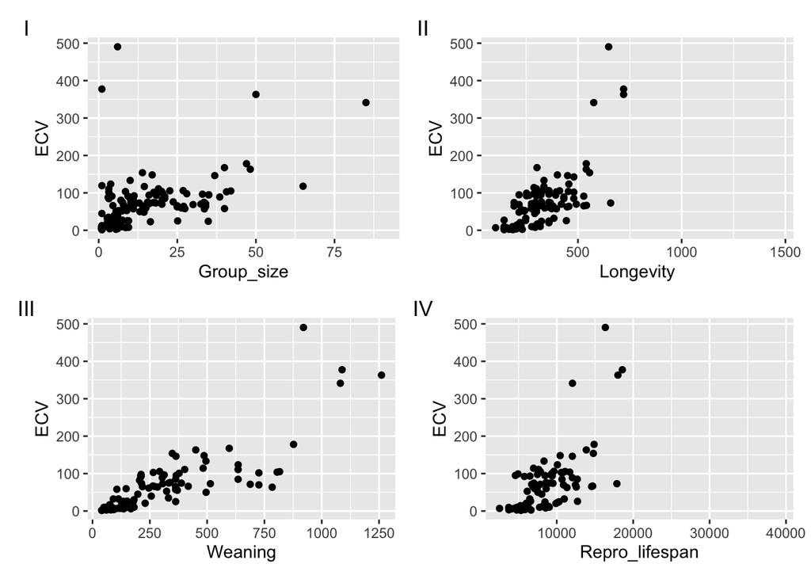

```r
library(ggplot2)
p1 <- ggplot(d, aes(x=Group_size, y=ECV)) +
  geom_point()
p2 <- ggplot(d, aes(x=Longevity, y=ECV)) +
  geom_point()
p3 <- ggplot(d, aes(x=Weaning, y=ECV)) +
  geom_point()
p4 <- ggplot(d, aes(x=Repro_lifespan, y=ECV)) +
  geom_point()

library(patchwork)
(p1 | p2)/ (p3 | p4) + plot_annotation(tag_levels = "I")
```

## Step 3: Manually derive regression coefficients for brain size as a function of social group size

```r
group_size <- d$Group_size
brain_size <- d$ECV

complete_data <- complete.cases(group_size, brain_size)

x <- group_size[complete_data]
y <- brain_size[complete_data]

# Calculate covariance manually
x_dev <- x - mean(x)
y_dev <- y - mean(y)
covariance <- sum(x_dev*y_dev) / (length(x)-1)

# Calculate variance manually
variance <- sum((x-mean(x))^2) / (length(x)-1)

(beta1 <- covariance / variance) # slope
```

```
[1] 2.463071
```

```r
(beta0 <- mean(y) - beta1 * mean(x)) # y-intercept
```

```
[1] 30.35652
```

## Step 4: Use ‘lm()’ to get regression coefficients

The beta coefficents using the ‘lm()’ function as the same as those manually calculated in Step 3.

```r
m <- lm(ECV~Group_size, data=d)
m$coefficients
```

```
(Intercept)  Group_size
  30.356524    2.463071
```

## Step 5: Calculate the regression coefficients for the three major primate radiations

By looking at them, the regression coefficients are different between the three groups.

```r
catarrhini <- filter(d, Taxonomic_group == "Catarrhini")
platyrrhini <- filter(d, Taxonomic_group == "Platyrrhini")
strepsirhini <- filter(d, Taxonomic_group == "Strepsirhini")

m_catarrhini <- lm(ECV~Group_size, data=catarrhini)
m_catarrhini$coefficients
```

```
(Intercept)  Group_size
  83.420592    1.146322
```

```r
m_platyrrhini <- lm(ECV~Group_size, data=platyrrhini)
m_platyrrhini$coefficients
```

```
(Intercept)  Group_size
  16.181212    1.965176
```

```r
m_strepsirhini <- lm(ECV~Group_size, data=strepsirhini)
m_strepsirhini$coefficients
```

```
(Intercept)  Group_size
   8.176384    1.840664
```

## Step 6a: Calculate standard error, p-value, and 95% confidence interval for the slope coefficient

```r
# Standard error of slope coefficent
MSE <- sum(m$residuals^2) / (length(x) - 2)
SSX <- sum((x-mean(x))^2)
manual_std_error <- sqrt(MSE / SSX)

# 95% confidence interval
slope <- as.numeric(m$coefficients[2])
t_value <- qt(0.975, df = length(x) - 2)
CI_lower <- slope  - t_value * manual_std_error
CI_upper <- slope  + t_value * manual_std_error

# p value
t_statistic <- slope / manual_std_error
manual_p_value <- 2 * (1 - pt(abs(t_statistic), df = length(x) - 2))

paste("The standard error is:", manual_std_error)
```

```
[1] "The standard error is: 0.350806075068323"
```

```r
paste("The 95% CI is:", paste(CI_lower, CI_upper))
```

```
[1] "The 95% CI is: 1.76987391333649 3.15626876763334"
```

```r
paste("p =", manual_p_value)
```

```
[1] "p = 7.259437495577e-11"
```

## Step 6b: Calculate standard error, p-value, and 95% confidence interval for the slope coefficient

```r
library(broom)

# Getting model results into a table
tidy_m <- broom::tidy(m)

# Pulling standard error
std_error <- tidy_m |>
  filter(term == "Group_size") |>
  pull(std.error)

# Pulling 95% confidence interval
CI <- confint(m, level = 0.95)[2,]

# Pulling p-value
p_value <- tidy_m |>
  filter(term == "Group_size") |>
  pull(p.value)

paste("The standard error is:", std_error)
```

```
[1] "The standard error is: 0.350806075068323"
```

```r
paste("The 95% CI is:", paste(CI, collapse = ", "))
```

```
[1] "The 95% CI is: 1.76987391333649, 3.15626876763335"
```

```r
paste("p =", p_value)
```

```
[1] "p = 7.25943489958251e-11"
```

## Step 7: Permutation approach to generate a null sampling distribution for the slope coefficient

**What is the p value associated with the original slope coefficient?** p = 7.25943489958251e-11

```r
library(mosaic)
n_perm <- 1000

# Original or "observed" slope coefficent
obs_slope <- tidy_m |>
  filter(term == "weight") |>
  pull(estimate)

perm <- do(n_perm) * {
  d_new <- d
  d_new$Group_size<- sample(d_new$Group_size)
  m <- lm(data = d_new, ECV~Group_size)
  broom::tidy(m) |>
    filter(term == "Group_size") |>
    pull(estimate)
}

# Calculate p-value
perm_p_value <- sum(perm$result > abs(obs_slope) | perm$result < -1 * abs(obs_slope))/n_perm
paste("p = ", perm_p_value)
```

```
[1] "p =  0"
```

## Step 8: Use bootstrapping to generate a 95% CI for the estimate of the slope coefficient using both the quantile method and the theory-based method

```r
library(infer)
# Bootstrapping
boot.slope <- specify(d, ECV~Group_size) |>
  generate(reps = 1000, type = "bootstrap") |>
  calculate(stat = "slope")
boot_vector <- boot.slope$stat

# Theoretical CI function
CI <- function(x, level = 0.95) {
    alpha <- 1 - level
    ci <- mean(x) + c(-1, 1) * qnorm(1 - (alpha/2)) * sqrt(var(x)/length(x))
    print(ci)
}
```

Both confidence intervals suggest that the slope is different from zero as neither confidence interval includes 0.

```r
# Quantile Method 95% CI
quantile(probs = c(0.025, 0.975), boot_vector)
```

```
    2.5%    97.5%
1.511142 3.291661
```

```r
# Theoretical Method 95% CI
CI(boot_vector)
```

```
[1] 2.417266 2.475024
```